# Figure 1A

Ivory Blakley

### Goal

Here, we want to recreate Figure 1A of Lax et al 2017.

We don’t have all of the samples they had, and differences in processing could affect some or all points. But we expect the figure as a whole to tell the same story.

In the legend, Figure 1A is described as:

> 1. Principal coordinate analysis (PCoA) of all floor samples based on weighted UniFrac distance and colored by whether they were taken before or after the hospital’s opening.

The source code and data-context for this can be found at: https://github.com/IvoryC/BuiltEnvData/tree/main/Chicago-Hostpital/09_remake_publication_fig1/script

## libraries

```r
suppressPackageStartupMessages({
  library(phyloseq)
  library(ggplot2)
  library(dplyr)
  library(ggrepel)
})
```

## counts data

```r
DADA2_part2 = dir("../..", pattern="DADA2_part2", full.names = T, include.dirs = T)
countsFile = file.path(DADA2_part2, "output", "asv-counts.txt")
counts = read.delim2(countsFile, row.names = 1)
dim(counts)
```

```
## [1] 3008  952
```

```r
counts = counts[rowSums(counts) > 0,]
dim(counts)
```

```
## [1] 2915  952
```

```r
head(row.names(counts))
```

```
## [1] "ERR1459793" "ERR1459883" "ERR1460576" "ERR1460577" "ERR1460578"
## [6] "ERR1460579"
```

```r
head(colnames(counts))
```

```
## [1] "ASV.1" "ASV.2" "ASV.3" "ASV.4" "ASV.5" "ASV.6"
```

## metadata

The meta is derived from the project metadata for SRA project PRJEB14474. Earlier, we simplified the table by reducing to just the columns of interest and the study_day feature out of sample names.

```r
metaReduced = dir("../..", pattern="metadata_PRJEB14474", full.names = T, include.dirs = T)
metaFile = file.path(metaReduced, "output", "PRJEB14474_SraRunTable_reduced.txt")
meta = read.delim2(metaFile)
row.names(meta) = meta$ID
message("Read metadata from: ", metaFile)
```

```
## Read metadata from: ../../02_review_metadata_PRJEB14474/output/PRJEB14474_SraRunTable_reduced.txt
```

We should have meta data for all samples we had data for…and for some samples that have been filtered out. Limit the meta data to only include samples we have in the data.

```r
inData = row.names(counts)
meta = meta[inData, ]
dim(meta)
```

```
## [1] 2915   14
```

We will need to describe days as being “pre-opening” or “post-opening”. This information is held is “study_day”. Make a new variable that is a simple category instead of a numeric.

```r
meta$opening = "before opening"
meta$opening[meta$study_day > 0] = "after opening"
```

There is a feature (surcat) that describes floor surfaces as being from rooms or stations. We want to simplify “Room_Surface” to “Room” for a nicer figure legend.

```r
meta$category = gsub(pattern="_Surface", "", meta$surcat)
```

## taxonomy

```r
assignTax = dir("../..", pattern="assign_ASV_taxonomy", full.names = T, include.dirs = T)
taxaFile = file.path(assignTax, "output/silva/asvTaxaTable_silva-v138.txt")
taxa = read.delim2(taxaFile, row.names = "asvID")
# drop the ASV column
taxaLim = taxa[,grep("ASV", names(taxa), invert = T, value = T)]
taxaMat = as.matrix(taxaLim)
```

# colors

Match the color scheme from the publication.

```r
myProjectPalette = c(
  'before opening'= "#2E5473",
  'after opening'= "#BB302F")
```

### Ordination function.

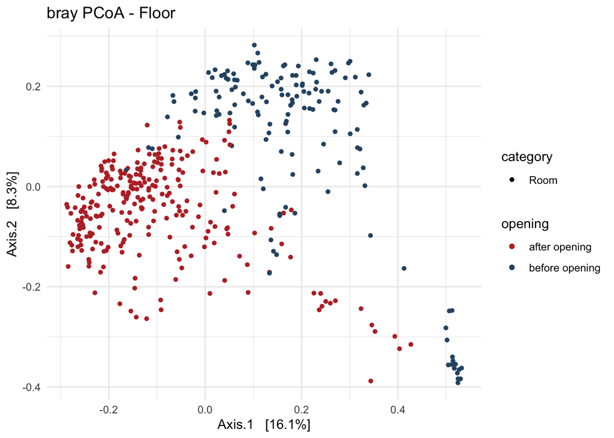

```r
# alt syntax:
# doPCoA = function(counts=counts, meta=meta, taxaMat=taxaMat, sampleType="Floor"){

doPCoA = function(sampleType="Floor"){
  sampleSet = meta[meta$SAMPLE_TYPE %in% sampleType, "ID"]
  countslim = counts[sampleSet,]

  ps <- phyloseq(otu_table(counts[sampleSet,], taxa_are_rows=FALSE),
                 sample_data(meta[sampleSet,]),
                 tax_table(taxaMat))
  ps.prop <- transform_sample_counts(ps, function(otu) otu/sum(otu))
  ord <- ordinate(ps.prop, method="PCoA", distance="bray") # TODO: switch to unifrac to match paper
  po = plot_ordination(ps.prop, ord, color="opening", shape="category",
                       title=paste0("bray PCoA - ", paste0(sampleType, collapse=", "))) +
    scale_colour_manual(values = myProjectPalette) +
    theme_minimal()
  return(list(ord=ord, plotA=po))
}
floor = doPCoA(sampleType="Floor")
floor$plotA
```

```r
# ggsave(file.path(outDir, "floor_bray_PCoA.png"))
```

### specific groups

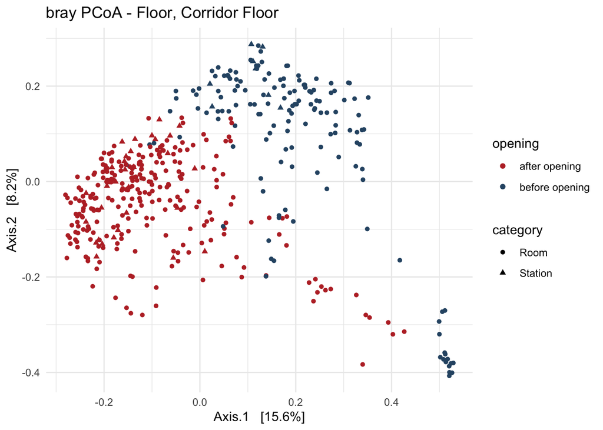

```r
a = doPCoA(sampleType=c("Floor", "Corridor Floor"))
show(a$plotA)
```

Remember that mirroring about one or both axes is arbitrary in an ordination plot.

This is a pretty good match for the story and shape we saw in the original figure. We are missing some data points, that may be why we don’t see the post-opening (red) samples that landed in the pre-opening range like they do in Figure A1 of the the paper.

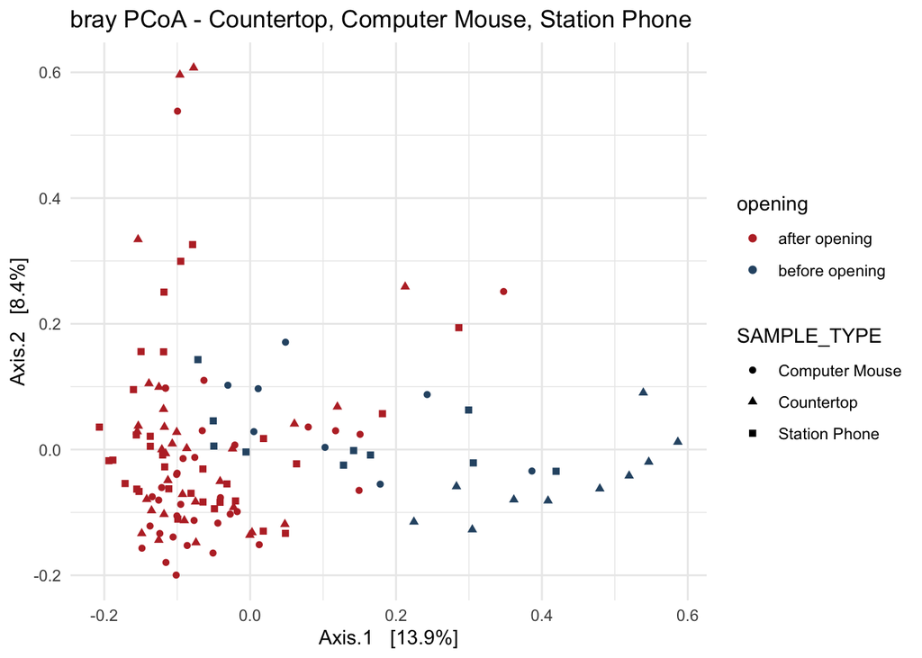

```r
b = doPCoA(sampleType=c("Countertop", "Computer Mouse", "Station Phone"))
b.shape = b$plotA + aes(shape=SAMPLE_TYPE)
show(b.shape)
```

The pre/post opening trend here looks like figure 1B, but I don’t think we have enough of the data points to see any similarity in terms of the sample types, and there weren’t any trends in that aspect anyway. This looks like a general match for the story even if it is a weak match for the shape.